# Project

2024-08-23

Load data from the NHL dataset from tidytuesday

Radar chard

```r
radar_chard <- joined_data %>% count(birth_month)

radar_chard <- radar_chard %>% mutate(
  max = 6000,
  min = 0
)

radar_chard <- radar_chard%>% relocate("max","min","n")


radar_chard <-  t(radar_chard)%>%as_tibble(,.name_repair)
```

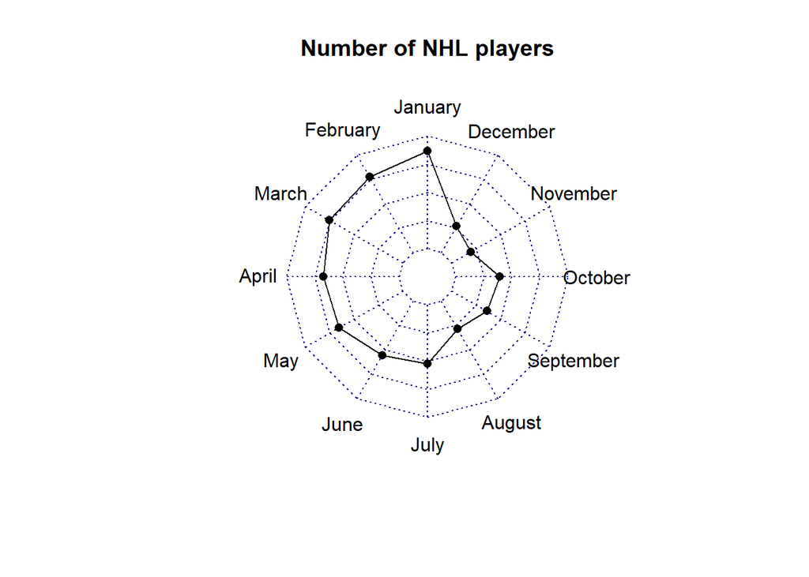

```r
radar_chard_plot <-radar_chard[-4,]


new_names<- c(January = "V1",
              February = "V2",
              March = "V3",
              April = "V4",
              May = "V5",
              June = "V6",
              July = "V7",
              August = "V8",
              September = "V9",
              October = "V10",
              November = "V11",
              December = "V12")

radar_chard_plot <- radar_chard_plot %>% rename(all_of(new_names))


radar_chard <- joined_data %>% count(birth_month)

radar_chard_3000 <- radar_chard %>% mutate(
  max = 6000,
  min = 3000
)

radar_chard_3000 <- radar_chard_3000 %>% relocate("max","min","n")


radar_chard_3000 <-  t(radar_chard_3000)%>%as_tibble(,.name_repair)
radar_chard_plot_3000 <-radar_chard_3000[-4,]

radar_chard_plot_3000 <- radar_chard_plot_3000 %>% rename(all_of(new_names))

radarchart(radar_chard_plot_3000, title = "Number of NHL players")
```

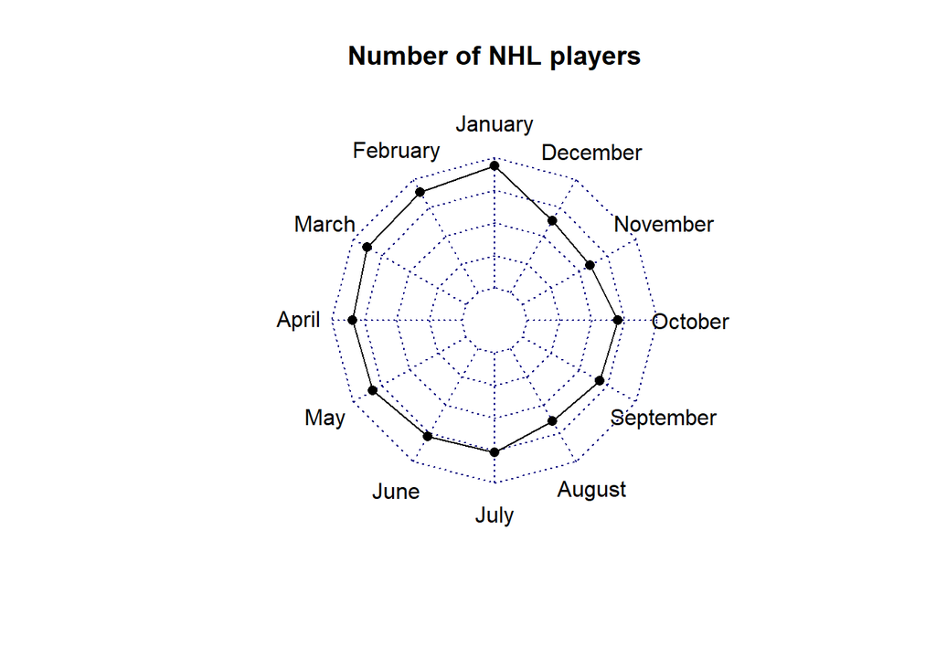

```r
radarchart(radar_chard_plot, title = "Number of NHL players")
```

#Histogram facet with position as well as season

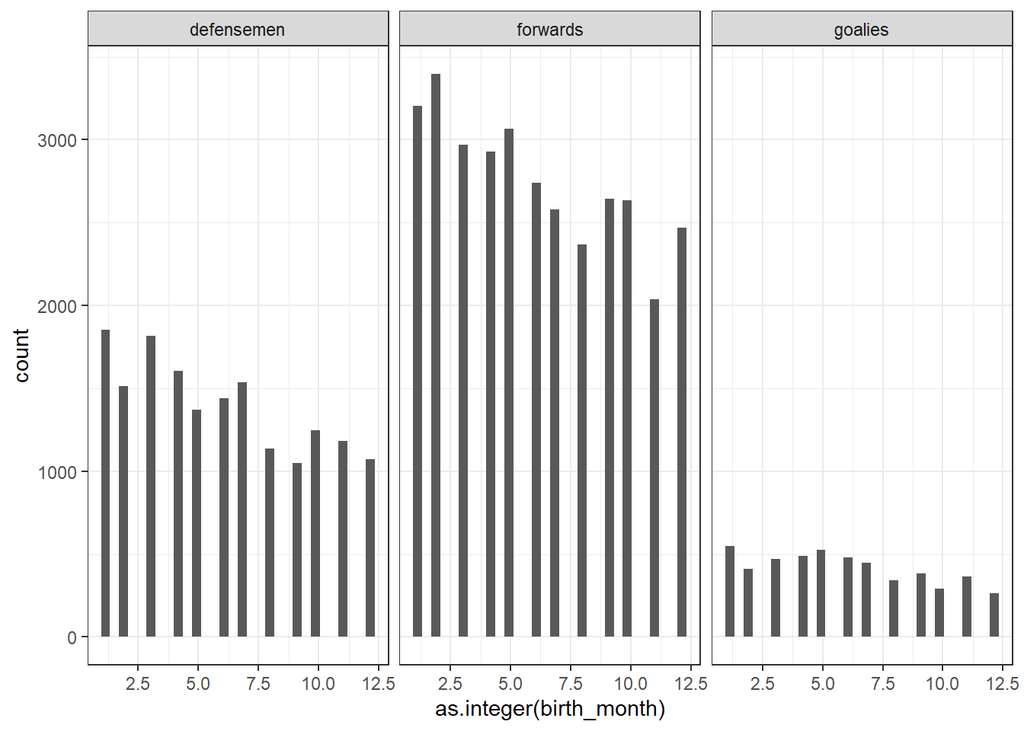

[figure not shown]

#Radar chard

radar_chard_1991 <- joined_data_1991 %>% count(birth_month)

canada_births %>% group_by(month) %>% summarise(total = sum(births)) %>% rename(birth_month = “month”) %>% left_join(., radar_chard_1991) %>% mutate(promille = n/total*1000, max = 1, min = 0) %>% select(max, min, promille) -> radar_chard_1991

radar_chard_1991 <- t(radar_chard_1991)%>%as_tibble(,.name_repair)

radar_chard_1991 <- radar_chard_1991 %>% rename(all_of(new_names))

## posirion

df_defensemen<-joined_data_1991 %>% filter(position_type == “defensemen”) df_forwards<-joined_data_1991 %>% filter(position_type == “forwards”) df_goalies<-joined_data_1991 %>% filter(position_type == “goalies”)

#Def radar_chard_1991_def <- df_defensemen %>% count(birth_month)

canada_births %>% group_by(month) %>% summarise(total = sum(births)) %>% rename(birth_month = “month”) %>% left_join(., radar_chard_1991_def) %>% mutate(promille = n/total*1000, max = 1, min = 0) %>% select(max, min, promille) -> radar_chard_1991_def

radar_chard_1991_def <- t(radar_chard_1991_def)%>%as_tibble(,.name_repair)

radar_chard_1991_def <- radar_chard_1991_def %>% rename(all_of(new_names))

# for

radar_chard_1991_for <- df_forwards %>% count(birth_month)

canada_births %>% group_by(month) %>% summarise(total = sum(births)) %>% rename(birth_month = “month”) %>% left_join(., radar_chard_1991_for) %>% mutate(promille = n/total*1000, max = 1, min = 0) %>% select(max, min, promille) -> radar_chard_1991_for

radar_chard_1991_for <- t(radar_chard_1991_for)%>%as_tibble(,.name_repair)

radar_chard_1991_for <- radar_chard_1991_for %>% rename(all_of(new_names))

# goal

radar_chard_1991_goal <- df_goalies %>% count(birth_month)

canada_births %>% group_by(month) %>% summarise(total = sum(births)) %>% rename(birth_month = “month”) %>% left_join(., radar_chard_1991_goal) %>% mutate(promille = n/total*1000, max = 1, min = 0) %>% select(max, min, promille) -> radar_chard_1991_goal

radar_chard_1991_goal <- t(radar_chard_1991_goal)%>%as_tibble(,.name_repair)

radar_chard_1991_goal <- radar_chard_1991_goal %>% rename(all_of(new_names))